# Análise da pesquisa: Quais são as influências das mídias sociais sobre discentes na unesp?

27 de novembro de 2018

## Introdução

O objetivo da pesquisa é coletar e analisar informações sobre o uso das mídias sociais pelos discentes da UNESP Bauru.

## Dados censitários

- A seguir serão apresentados as representações gráficas dos seguintes dados:
- Gênero
- Idade
- Situação Trabalhista Atual
- Estado Civil

## Gênero

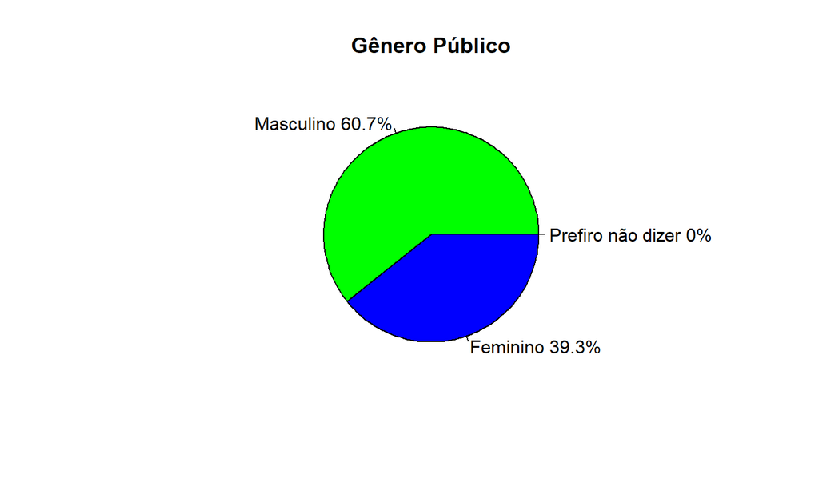

## Idade

[figure not shown]

## Situação Trabalhista Atual

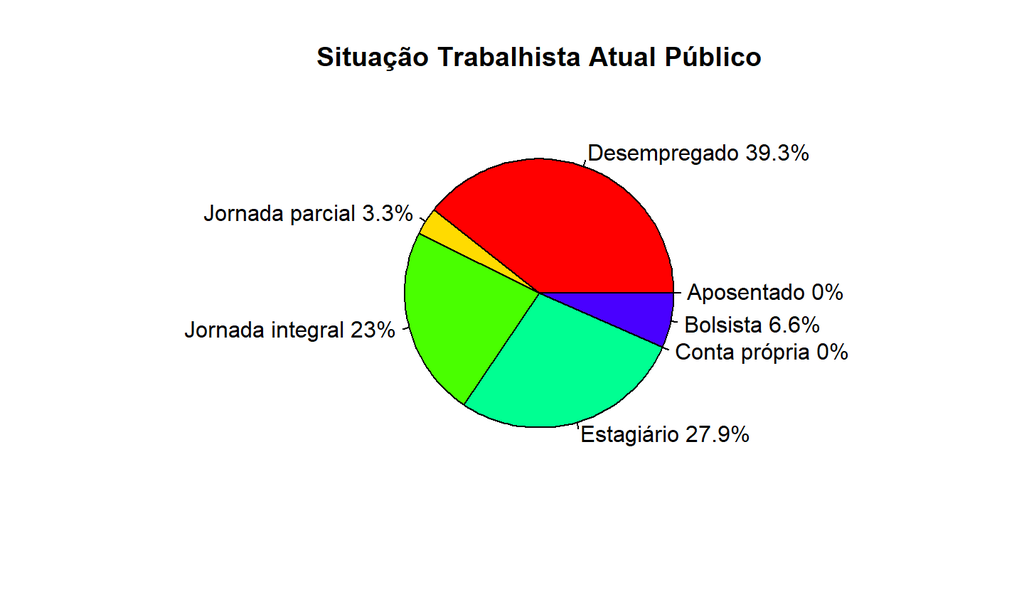

## Estado Civil

[figure not shown]

## Dados sobre o uso das mídias sociais

- A seguir serão apresentados as representações gráficas dos dados obtidos sobre o uso das mídias sociais:
- Plataformas mais utilizadas
- Motivos pelo qual o pública usa
- Tempo gasto em redes sociais
- Opinião sobre mídias serem utilizadas pelos professores
- Opinião sobre forma de aproximação dos professores
- Opinião sobre melhora no resultado dos alunos

## Plataformas mais utilizadas

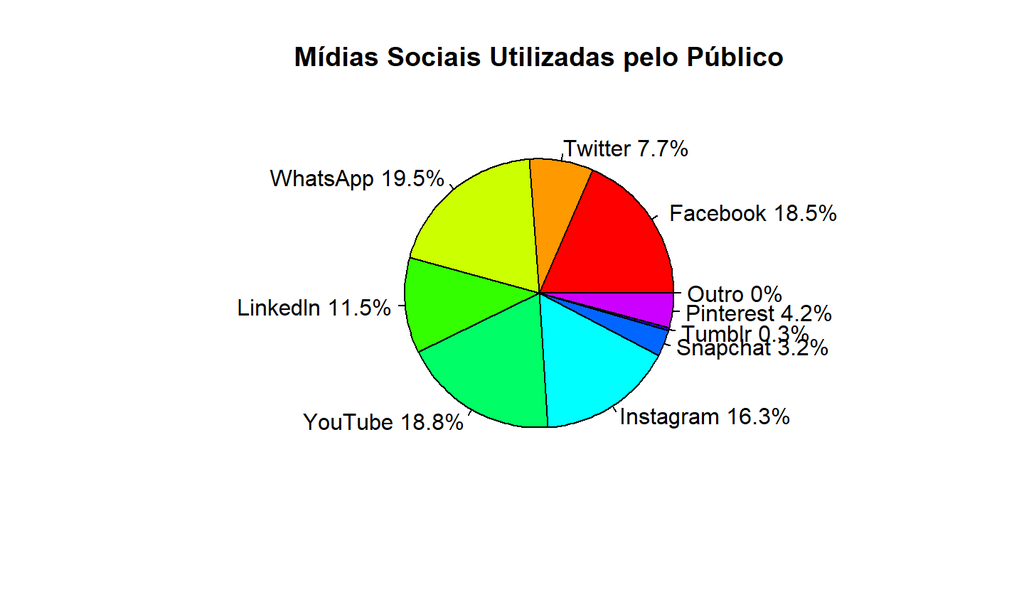

## Motivos pelo qual o público usa redes sociais

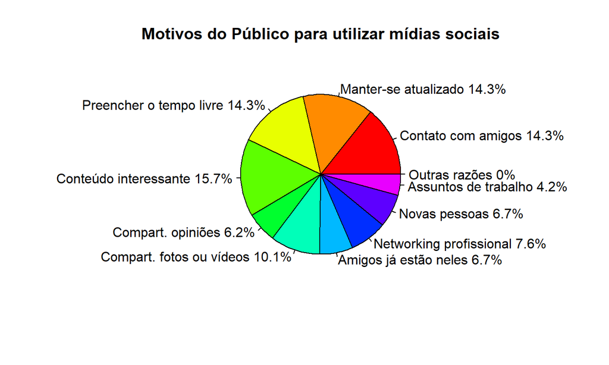

## Tempo gasto em redes sociais

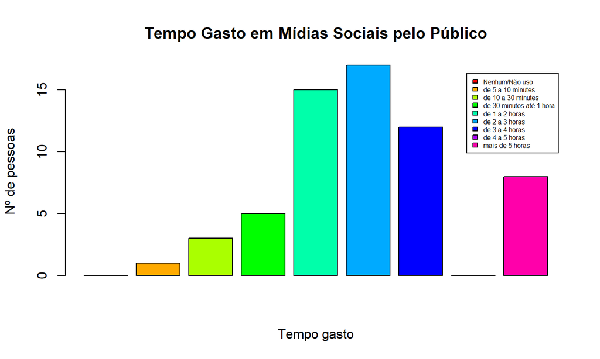

## Opinião sobre mídias serem utilizadas pelos professores

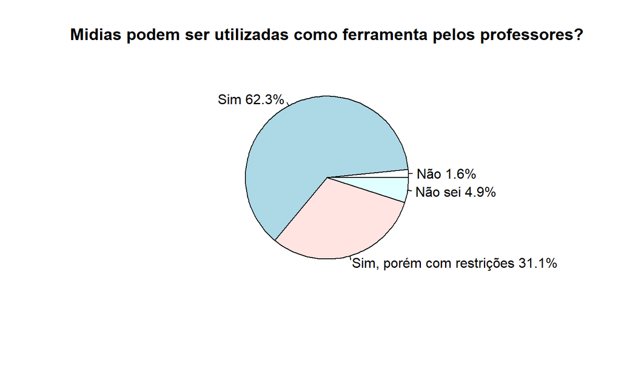

## Opinião sobre forma de aproximação dos professores

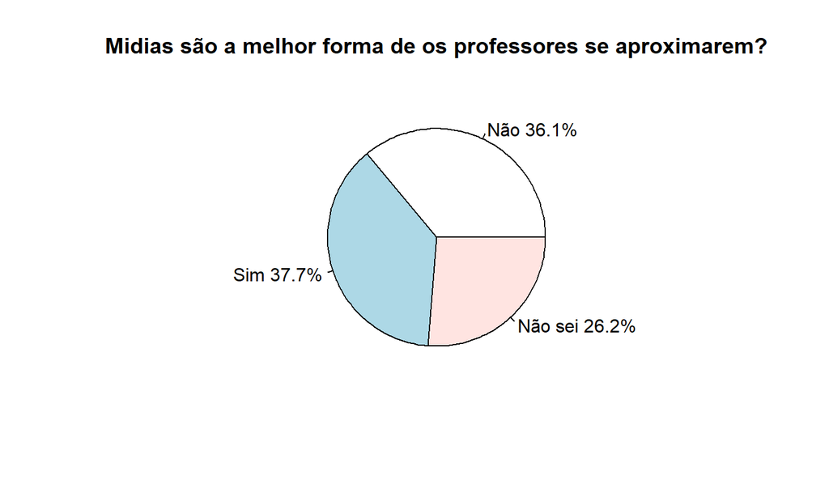

## Opinião sobre melhora no resultado dos alunos

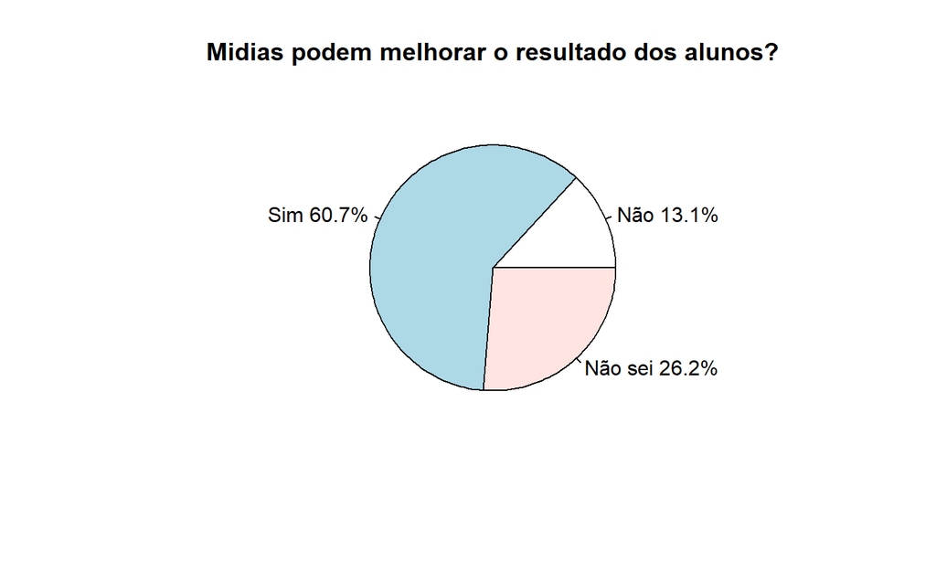

## Análises - Dados cruzados

- Cruzamos alguns dados da pesquisa para analisar os resultados de um outro ponto de vista. As análises serão apresentadas a seguir.

## Análise de opinião sobre mídia como ferramenta e forma de professores se aproximarem

- O gráfico a seguir mostra a opinião do público que apoia a utilização de mídias como ferramenta de aprendizagem de alunos e que também acredita ou não que essa prática seria a melhor forma de aproximação de alunos com seus respectivos professores.

## Análise de opinião sobre mídia como ferramenta e forma de professores se aproximarem

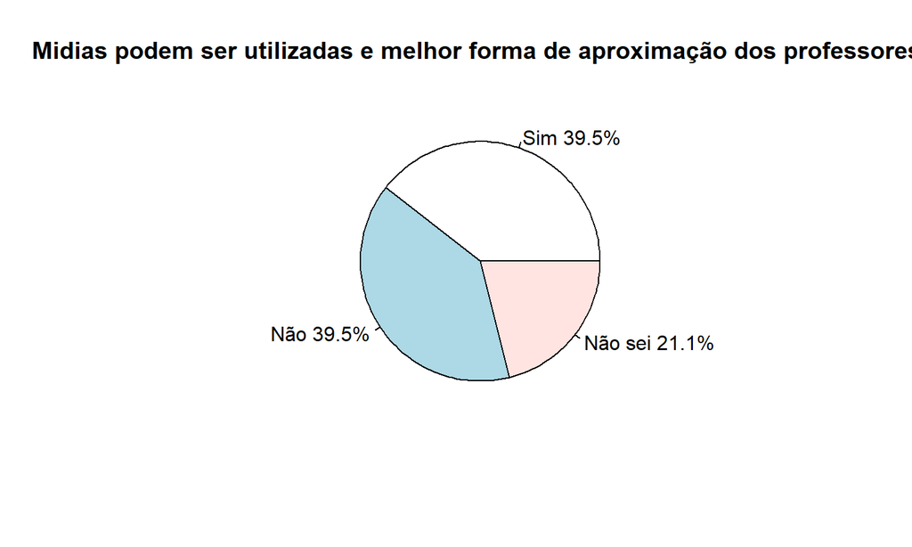

- Há um empate em relação à opinião dos nossos entrevistados: cerca de 39,5% do público acredita que a prática de utilizar mídias em salas de aula seria de grande valia e também que traria uma maior aproximação dos professores com seus respectivos alunos. -Enquanto isso, também 39,5% dos entrevistados defendem a utilização das mídias, mas não acreditam que traria benefícios para estreitar o vínculo professor/aluno. Já os 21,1% restantes das respostas acreditam na utilização das mídias para ensino, mas não sabem dizer se traria vantagem social aos envolvidos. -Isso nos mostra que, apesar dos nossos entrevistados serem alunos de tecnologia em sua grande maioria, ainda há uma certa dúvida e/ou receio quanto a utilização das mídias para fortalecer a relação entre professores e alunos.

## Análise de opinião sobre mídia como ferramenta e sobre melhorar o resultado dos alunos

- O gráfico a seguir mostra a opinião do público que apoia a utilização de mídias como ferramenta de aprendizagem de alunos e que também acredita ou não que essa prática traria melhores resultados para os mesmos.

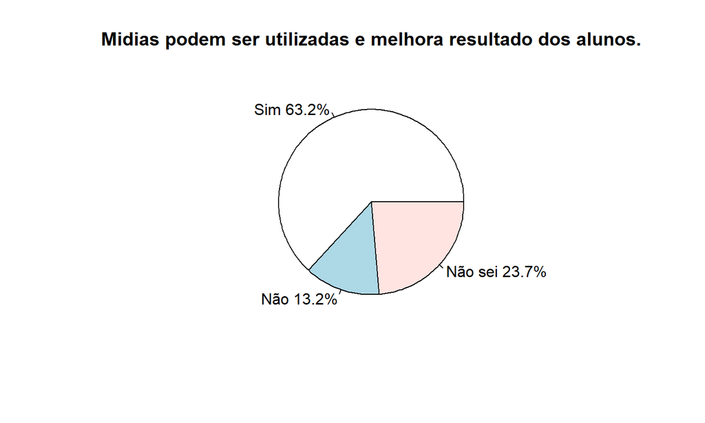

- Cruzando nossas informações e criando o gráfico, podemos notar que a grande maioria dos nossos entrevistados acredita na utilização das mídias por meio de professores, seja para fortalecer a relação professor/aluno ou também para auxiliar no aprendizado e passagem de conteúdos escolares. Dessa forma, podemos notar que a adesão da tecnologia no meio estudantil está cada vez mais em ascensão, principalmente entre alunos que estudam esse assunto. Consideramos esse resultado positivo, pois a internet e as mídias em geral têm muito a oferecer que possa ser de grande valia para a assimilação de conteúdos. Além disso, trata-se de um resultado, em partes, esperado, já que o público entrevistado tem grande aderência às redes sociais e mídias em geral, muitas vezes utilizando-as para estudos e aprendizado a distância.

## Análise de opinião sobre mídia como forma de aproximação e sobre melhorar o resultado dos alunos

- O gráfico a seguir mostra a opinião do público que apoia a utilização de mídias como forma de aproximação dos professores e que também acredita ou não que essa prática traria melhores resultados para os mesmos.

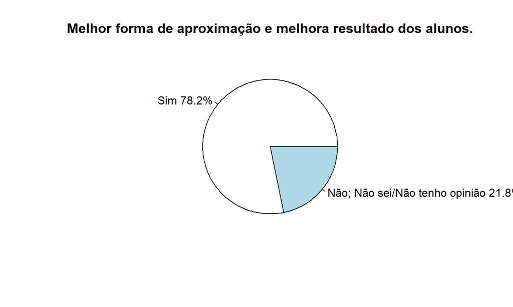

O resultados do gráfico “Melhor forma de aproximação e melhora resultado dos alunos” mostram que 78,2% das pessoas que responderam ambas perguntas acreditam que as mídias sociais são a melhor forma de aproximação de professores e alunos e também acreditam que a utilização delas melhora os resultados dos alunos. O restante, 21,8%, discorda que algumas dessas afirmações ou não sabem/não têm opinião.

## Análise de opinião sobre mídia para melhorar resultados e como fonte de distração

- O gráfico abaixo mostra o cruzamento de respostas dos entrevistados que acreditam que as mídias utilizadas no meio educativo trariam melhores resultados, porém que também serviriam como fonte de distração.

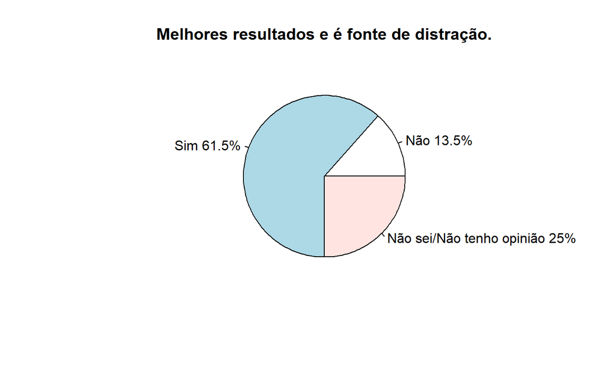

## Análise de opinião sobre mídia para melhorar resultados e sobre instituições usando por motivos promocionais

- O gráfico abaixo mostra a opinião de quem acredita que a mídia social é a melhor forma dos professores se aproximarem de seus alunos e sobre o número crescente de instituições educacionais está usando mídias sociais por motivos promocionais.

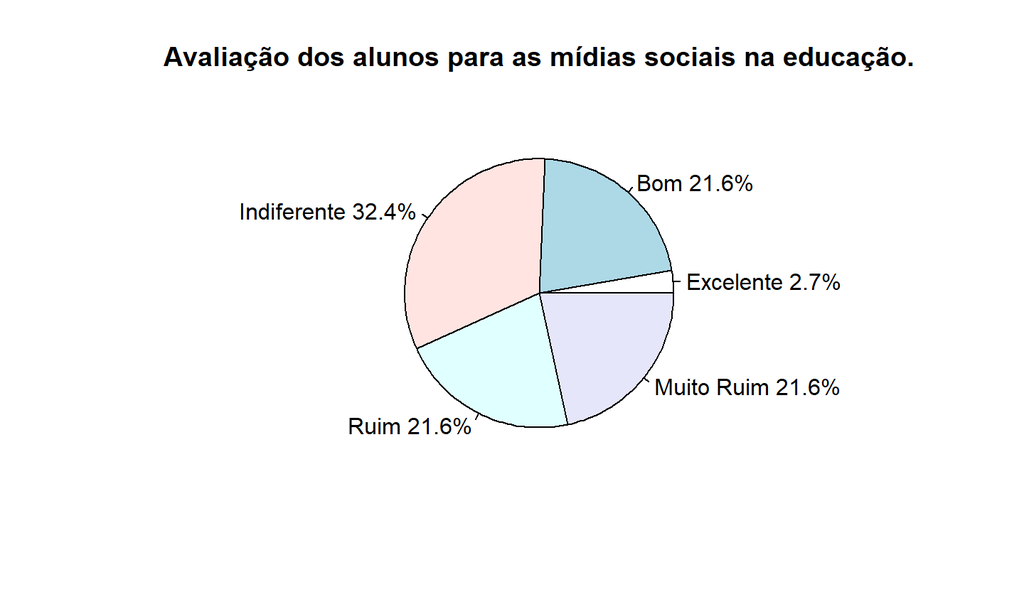

Cruzando nossas informações e criando o gráfico, podemos notar que a maioria dos nossos entrevistados - cerca de 32,4% - é indiferente em relação a utilização das mídias sociais no meio da educação. Por outro lado, 21,6% afirma que essa prática seria válida e boa, apesar da mesma porcentagem crer que essa utilização seria “Ruim” e/ou “Muito Ruim”. Por fim, apenas 2,7% dos nossos entrevistados acredita que essa atividade seria excelente, tendo muito a agregar ao aluno. Nesse estudo, podemos ver uma relutância por meio dos entrevistados na utilização das mídias sociais no meio educativo, talvez por intensificarem a falta de atenção do aluno e promoverem a perda de foco.

## Análise de opinião sobre mídias sociais utilizadas pelo público entre 16 e 20 anos

- O gráfico abaixo nos mostra a aderência à determinadas redes sociais (WhatsApp, Facebook, Twitter, Snapchat, Instagram, Tumblr, Pinterest, Youtube, LinkedIn e Outros) pelo nosso público numa faixa etária de 16 a 20 anos.

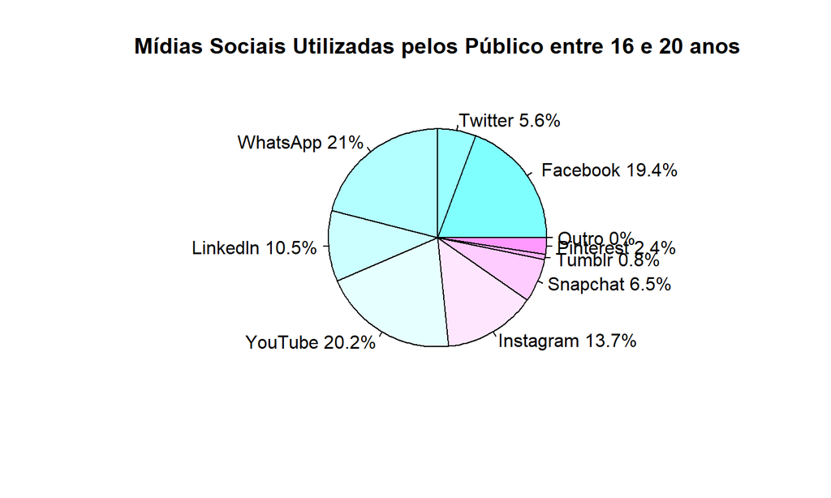

Questionamos nossos entrevistados acerca da rede social mais usada por eles no dia-a-dia e, como podemos notar avaliando o gráfico, a maior aceitação é relacionada ao WhatsApp, sendo utilizado por cerca de 21% da nossa amostra. Em segundo lugar encontra-se o Youtube com 20,2%, seguido pelo Facebook com 19,4% e pelo Instagram com 13,7%. Acreditamos que o resultado desse cruzamento de informações é bem característico da faixa etária avaliada, de fato: onde adolescentes passam a maior parte do tempo em redes sociais que promovem a socialização entre conhecidos e amigos como, por exemplo, WhatsApp, Facebook e Instagram. Possivelmente, a aderência ao Youtube diz respeito à visualização de clipes musicais e artísticos.

## Análise de opinião sobre mídias sociais utilizadas pelo público entre 21 e 25 anos

- O gráfico abaixo nos mostra a aderência à determinadas redes sociais (WhatsApp, Facebook, Twitter, Snapchat, Instagram, Tumblr, Pinterest, Youtube, LinkedIn e Outros) pelo nosso público numa faixa etária de 21 a 25 anos.

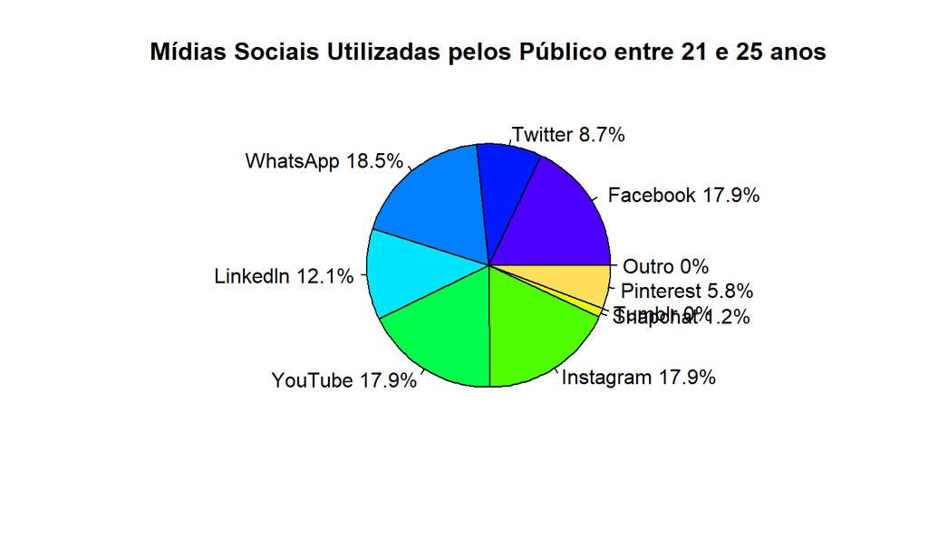

Questionamos nossos entrevistados acerca da rede social mais usada por eles no dia-a-dia e, como podemos notar avaliando o gráfico, a maior aceitação ainda é relacionada ao WhatsApp, sendo utilizado por cerca de 18,5% da nossa amostra. Em segundo lugar encontra-se um empate entre Youtube, Facebook e Instagram com 17,9% cada um, seguido pelo LinkedIn com 12,1%.Acreditamos que o resultado desse cruzamento de informações também é bem característico da faixa etária avaliada: onde há um crescimento na porcentagem de utilização do LinkedIn (provavelmente por busca de empregos e estágios, visto que a amostra deste gráfico encontra-se numa faixa etária mais interessada em ingressar no mercado de trabalho).

## Análise sobre motivos porque os jovens de 16 a 20 anos usam mídias sociais

- O gráfico abaixo nos mostra o motivo da aderência à determinadas mídias por meio do nosso público presente na faixa etária de 16 a 20 anos.

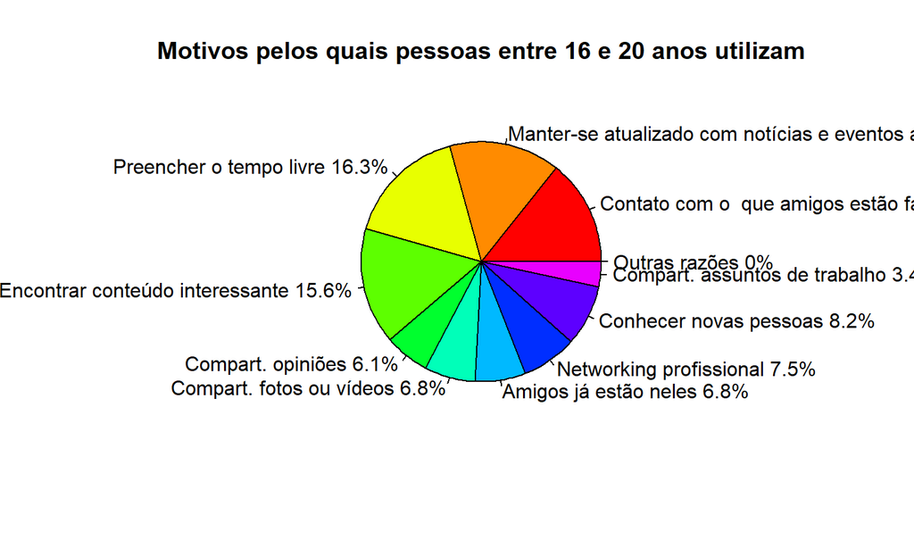

Segundo nosso gráfico, em primeiro lugar encontra-se a porcentagem dos nossos entrevistados que utilizam as mídias apenas para passar o tempo, somando cerca de 16,3%. Já em segundo lugar, estão presentes aqueles que acessam as mídias com o objetivo de encontrar conteúdos interessantes, totalizando 15,6%. Continuando nossa análise, 15% representam aqueles entrevistados que utilizam as mídias para manter-se atualizados com notícias e eventos atuais e 14,3% representam aqueles que buscam apenas contato com o que os amigos estão fazendo. Por fim, as opções menos votadas são: para conhecer novas pessoas (8,2%), networking profissional (7,5%), compartilhamento de fotos e vídeos (6,8%), por causa de amigos que já estão conectados nas mídias (6,8%), para o compartilhamento de opiniões (6,1%) e para o compartilhamento de assuntos de trabalho (3,4%). Podemos notar que nossos entrevistados abrangem diversos motivos para a utilização das mídias no dia-a-dia e acreditamos que isso se dá graças a versatilidade do mundo da internet.

## Análise sobre motivos porque jovens de 21 e 25 anos usam mídias sociais

- O gráfico abaixo nos mostra o motivo da aderência à determinadas mídias por meio do nosso público presente na faixa etária de 21 a 25 anos.

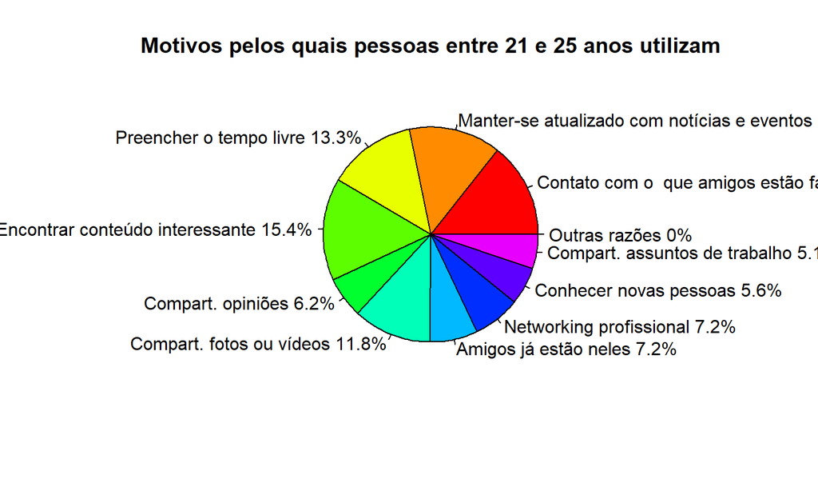

Segundo nosso gráfico, em primeiro lugar encontra-se a porcentagem dos nossos entrevistados que utilizam as mídias para encontrar conteúdos interessantes, somando cerca de 15,4%. Já em segundo lugar, estão presentes aqueles que acessam as mídias com o objetivo de acompanhar o que os amigos estão fazendo, totalizando 14,4%. Continuando nossa análise, 13,8% representam aqueles entrevistados que utilizam as mídias para manter-se atualizados com notícias e eventos atuais e 13,3% representam aqueles interessados apenas em preencher o tempo livre. Podemos notar que nossos entrevistados abrangem diversos motivos para a utilização das mídias no dia-a-dia e acreditamos que isso se dá graças a versatilidade do mundo da internet.

## Análise sobre situação trabalhista atual do público que utiliza LinkedIn

- O gráfico abaixo nos mostra a situação trabalhista atual do público que utiliza LinkedIn.

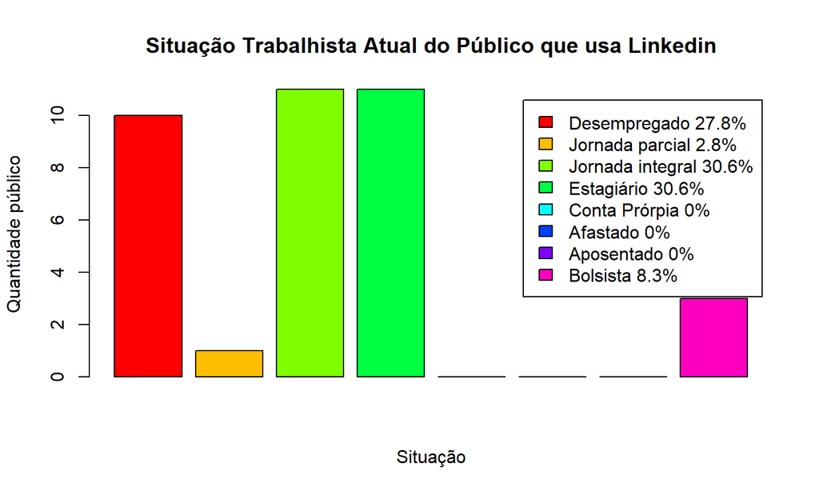

O gráfico de “Situação trabalhista do público que usa LinkedIn” mostra que dentre os participantes da pesquisa que utilizam o LinkedIn, os estagiários e colaboradores de tempo integral estão empatados com 30.6% cada. Seguindo na ordem decrescente, temos os desempregados, que somam 27,8% dos participantes e bolsistas com 8,3%. Os perfis de pessoas com conta própria, afastadas e aposentadas, dentre os pesquisados, são 0%.

## Análise sobre melhora de resultados e troca de arquivos

- O gráfico abaixo representa como os participantes julgam que os alunos alcançarão melhores resultados se as mídias sociais estiverem integradas às aulas e/ou atividades e que avaliam os membros dos grupos poderem trocar arquivos, links, informações, pesquisas e vídeos rapidamente como excelente.

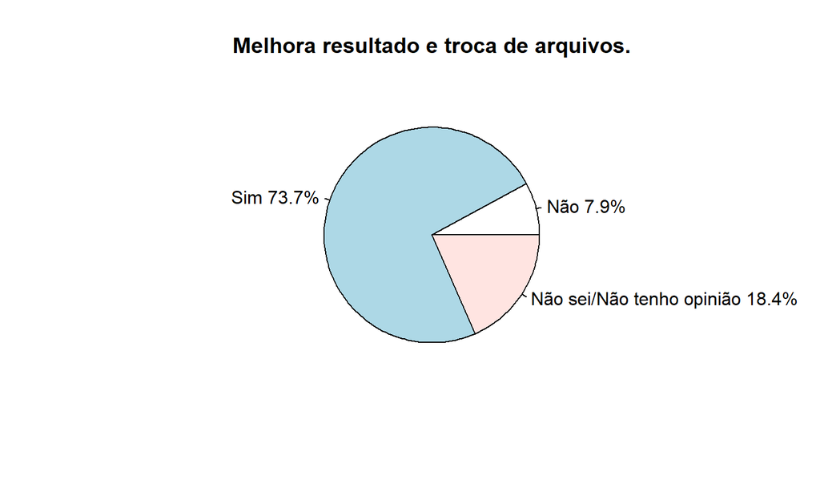

## Análise da relação de uso do Pinterest

- O gráfico abaixo mostra que dentre os entrevistados que utilizam o pinterest quais acham excelente,bom,indiferente, ruim ou muito ruim o uso da mídia para compartilhamento de quadros virtuais e conteúdos multimídia entre os alunos.

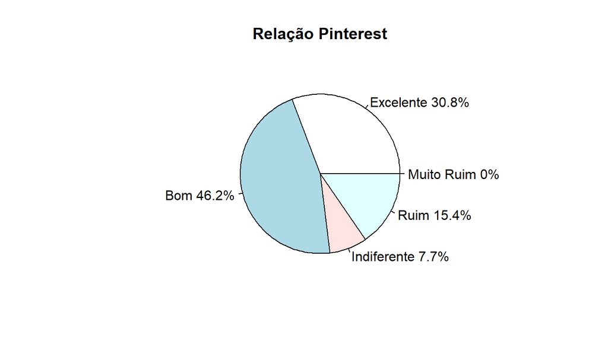

Cruzando nossas informações e criando o gráfico, podemos notar que a maioria dos nossos entrevistados - cerca de 46,2% - acredita que seria “Bom” o uso e 30,8% acreditam que seria “Excelente”, o que podemos interpretar que nossos entrevistados acham que agregaria aos alunos. Por outro lado, 15,4% acreditam que o uso seria “Ruim” e 0% que seria “Muito ruim”, mostrando que uma pequena parcela dos nossos entrevistados acreditam que seria algo maléfico para os alunos. Além disso 7,7% se mostraram indiferentes quanto o uso.

## Análise da relação de uso do Facebook

- O gráfico abaixo mostra que dentre os entrevistados que utilizam o facebook quais acham excelente,bom,indiferente, ruim ou muito ruim o uso de grupos do facebook pelas escolas para fazer a comunicação com os alunos.

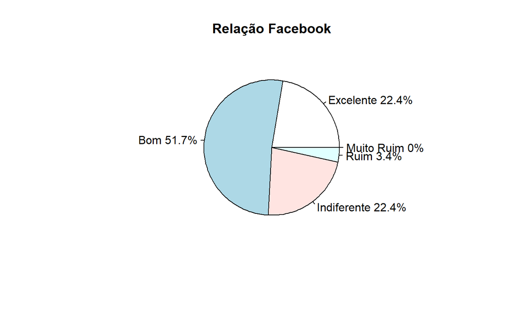

Cruzando nossas informações e criando o gráfico, podemos notar que a maioria dos nossos entrevistados - cerca de 51,7% - acredita que seria “Bom” o uso e 22,4% acreditam que seria “Excelente”, o que podemos interpretar que nossos entrevistados acham que agregaria aos alunos. Por outro lado, os mesmos 22,4% que acham excelente também acham que seria “Indiferente” e não agregaria em nada. Apenas 3,4% acreditam que o uso seria “Ruim” e 0% que seria “Muito ruim”, mostrando que poucos dos nossos entrevistados acreditam que seria algo maléfico para os alunos.

## Conclusão

- Foram analisadas as amostras populacionais e sua utilização das mídias sociais
- Pode-se comprovar padrões de conceitos estabelecidos pelos sociólogos referentes à geração Y
- Pode-se extrair melhorias para às aulas, para professores e alunos
- Pode-se dizer que o uso da tecnologia impacta em muitos fatores relacionados aos alunos
- Como sugestão, fica a tentativa de aumentar a amostra para que os dados sejam ainda mais precisos na próxima pesquisa.